# Presentation

Max

1/17/2017

## Data

The training data for this project are available here: https://d396qusza40orc.cloudfront.net/predmachlearn/pml-training.csv

The test data are available here: https://d396qusza40orc.cloudfront.net/predmachlearn/pml-testing.csv

The data for this project come from this source: http://groupware.les.inf.puc-rio.br/har.

## Loading and cleaning data

First, we will download the data file and clean the empty values:

```r
training = read.csv(url("http://d396qusza40orc.cloudfront.net/predmachlearn/pml-training.csv"), na.strings = c("NA", "#DIV/0!"))
testing = read.csv(url("http://d396qusza40orc.cloudfront.net/predmachlearn/pml-testing.csv"), na.strings = c("NA", "#DIV/0!"))
```

We can see that there are quite a lot of variables (160) and we don’t need all of them. The next step will be to continue to clean the data and remove teh useless variables, as seen during the different lessons. We can begin to remove the near zero variance predictors:

```r
zero <- nearZeroVar(training)
training <- training[, -zero]
dim(training)
```

```
## [1] 19622   124
```

We have now 124 variables which is still a lot. Some have a lot of NA and will pollute the data some we can also remove them:

```r
naval    <- sapply(training, function(x) mean(is.na(x))) > 0.95
training <- training[, naval == FALSE]
dim(training)
```

```
## [1] 19622    59
```

Now taht we reduced to 59 variables, we can also remove the useless 5 first columns that are just here for identification:

```r
training <- training[, -(1:5)]
dim(training)
```

```
## [1] 19622    54
```

Let’s now create the partition fro the training data to create a new training (70%) and testing (30%) dataset:

```r
Train  = createDataPartition(training$classe, p = 0.7, list = FALSE)
TrainSet = training[Train, ]
TestSet  = training[-Train, ]
dim(TrainSet)
```

```
## [1] 13737    54
```

```r
dim(TestSet)
```

```
## [1] 5885   54
```

Finally, let’s see the correlation:

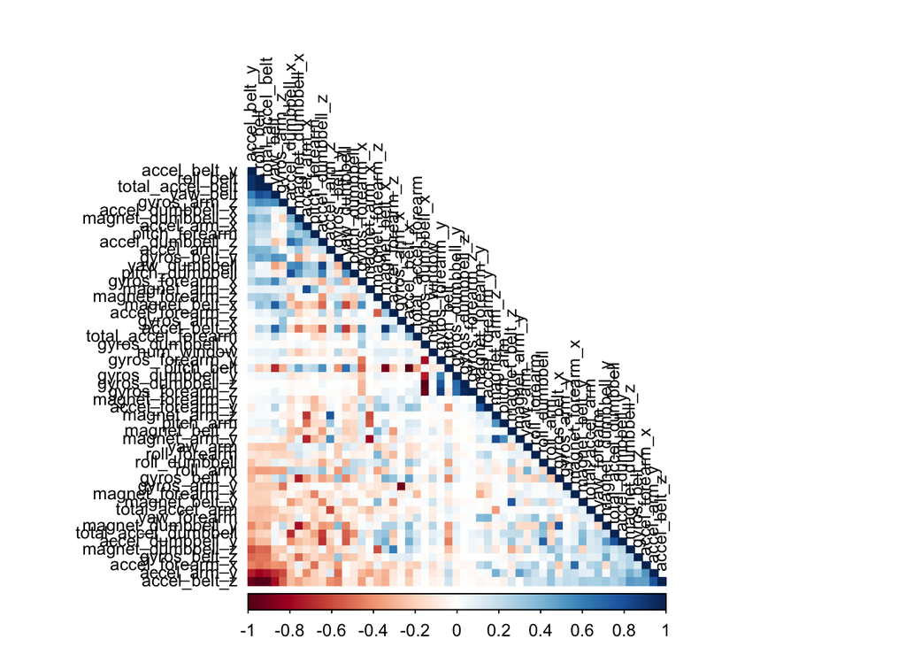

```r
correl <- cor(TrainSet[, -54])
corrplot(correl, order = "FPC", method = "color", type = "lower", tl.cex = 0.8, tl.col = rgb(0, 0, 0))
```

## Testing the different models and selecting the best one with cross validation

Let’s try the different possibilities offered by teh caret package.

1. rpart

```r
cv3 = trainControl(method = "cv", number = 3, allowParallel = TRUE, verboseIter = TRUE)
mtree = train(classe~., data = training, method = "rpart", trControl = cv3)
ptree = predict(mtree, training)
table(ptree, training$classe)
```

```
##
## ptree    A    B    C    D    E
##     A 5080 1581 1587 1449  524
##     B   81 1286  108  568  486
##     C  405  930 1727 1199  966
##     D    0    0    0    0    0
##     E   14    0    0    0 1631
```

2. randomForest

```r
mrf = train(classe~., data = training, method = "rf", trControl = cv3)
prf = predict(mrf, training)
table(prf, training$classe)
```

```
##
## prf    A    B    C    D    E
##   A 5580    0    0    0    0
##   B    0 3797    0    0    0
##   C    0    0 3422    0    0
##   D    0    0    0 3216    0
##   E    0    0    0    0 3607
```

## testing on the testing data

Now we can test the model on the testing data

```r
prf2 = predict(mrf, testing)
ptree2 = predict(mtree, testing)
table(prf2, ptree2)
```

```
##     ptree2
## prf2 A B C D E
##    A 7 0 0 0 0
##    B 3 0 5 0 0
##    C 0 0 1 0 0
##    D 0 0 1 0 0
##    E 1 0 2 0 0
```

## Predict 20 different test cases

```r
answers = predict(mrf, testing)
answers
```

```
##  [1] B A B A A E D B A A B C B A E E A B B B
## Levels: A B C D E
```